# Programme LIFT pour la MEL - août 2022

Cas d’usage : Quelle est la part des TPME dans les titulaires de marchés publics conclus par ma commune ? Ces titulaires sont-ils des entreprises locales ?

Ce cas d’usage a pour objectif de valoriser les données essentielles de la commande publique (DECP) en qualifiant les titulaires de 6 territoires définis. Nous analysons ainsi les données des marchés publics de 6 communes :

- la ville de **Lambersart** ;
- la ville d’**Haubourdin** ;
- la ville de **Lille** ;
- la ville de **Croix** ;
- la ville de **Ronchin** ;
- la ville de **Roubaix**.

## En résumé

- **Récapitulatif pour 2019**

type

acheteur

nombre de titulaires et part des TPME

nombre d'entreprises et part des TPME

nombre de marchés moyen par entreprise

part des entreprises locales

Lambersart

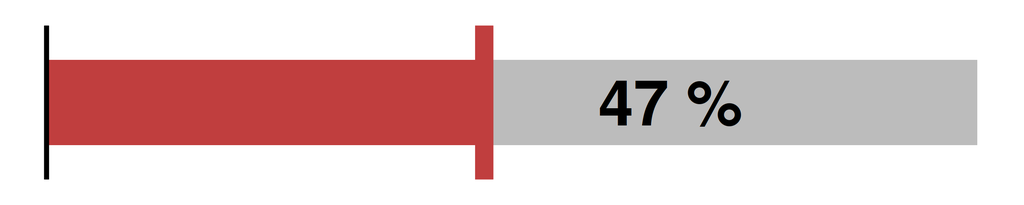

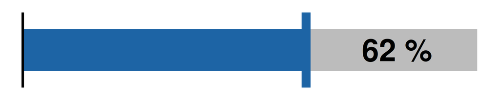

1.5

59 %

Lille

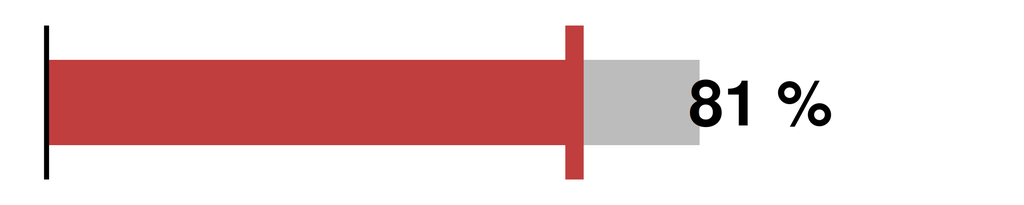

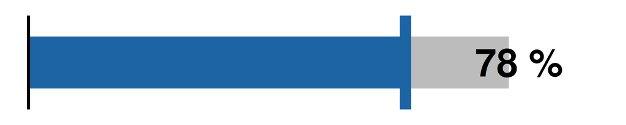

1

72 %

Croix

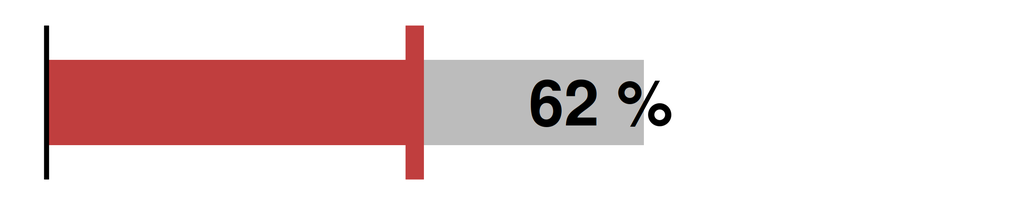

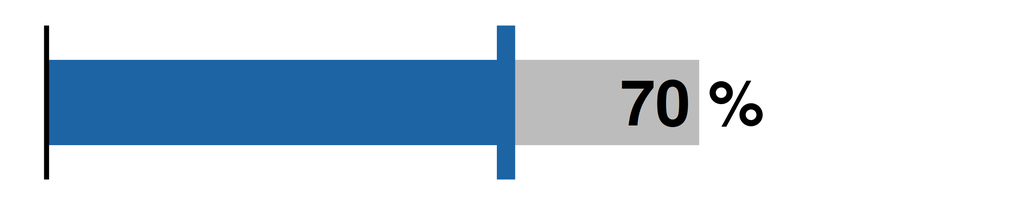

0.6

75 %

Ronchin

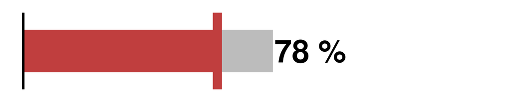

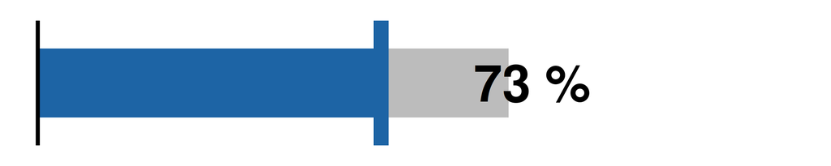

1.5

80 %

Roubaix

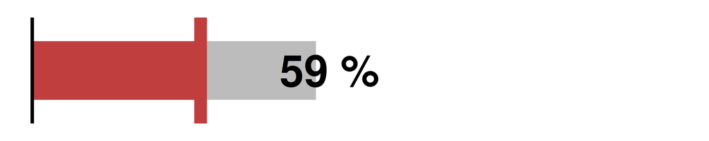

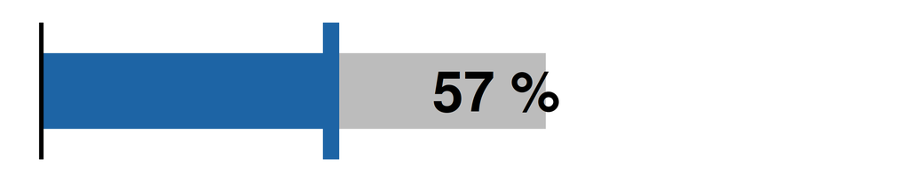

1.3

68 %

Haubourdin

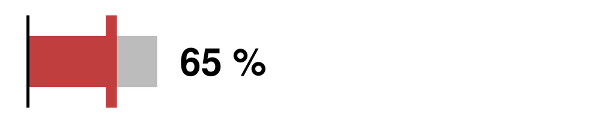

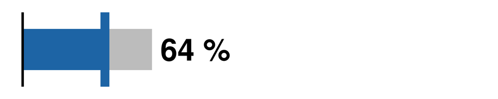

1.4

59 %

Données essentielles de la commande publique (DECP) - année 2019

- **Récapitulatif pour 2020**

type

acheteur

nombre de titulaires et part des TPME

nombre d'entreprises et part des TPME

nombre de marchés moyen par entreprise

part des entreprises locales

Lille

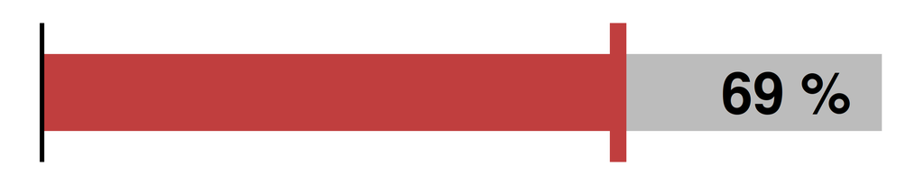

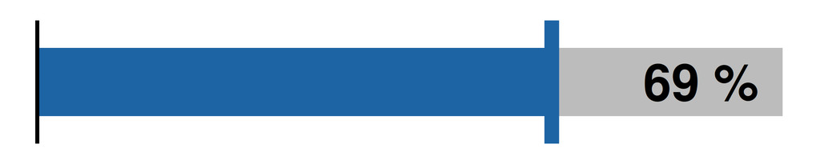

1.3

65 %

Roubaix

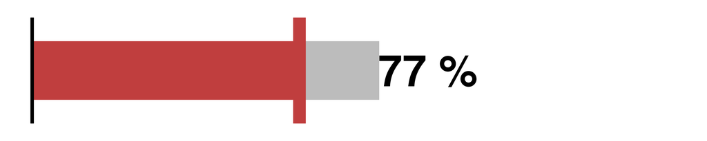

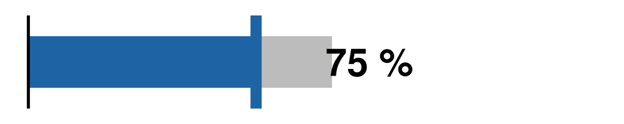

1.6

73 %

Lambersart

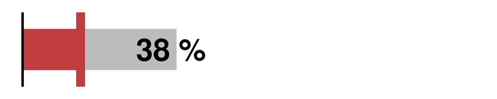

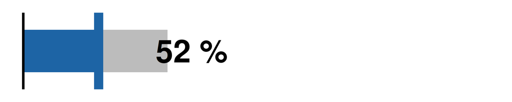

1.5

51 %

Croix

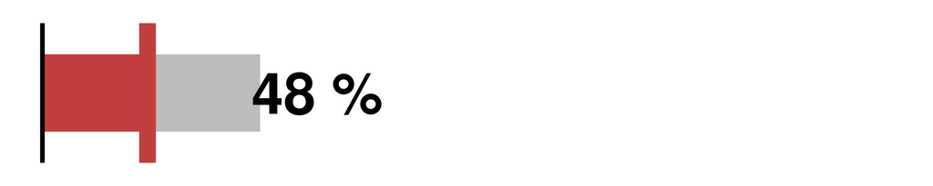

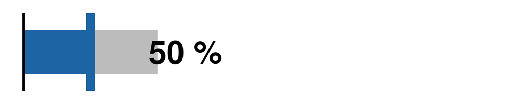

1.1

63 %

Ronchin

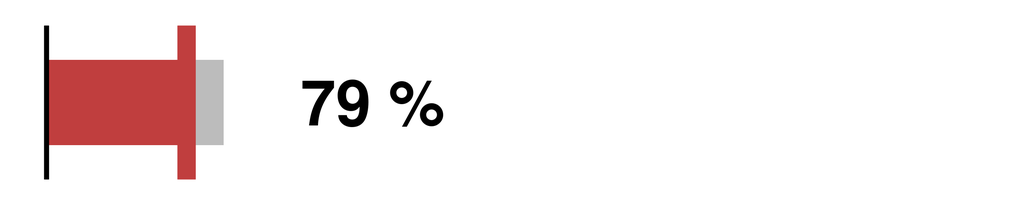

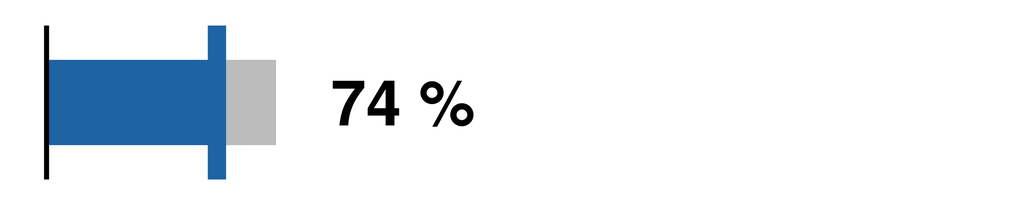

1.2

68 %

Haubourdin

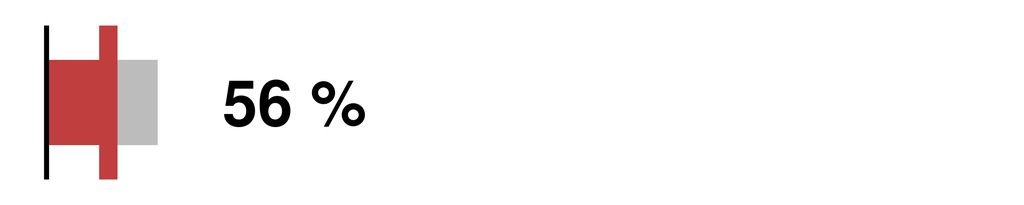

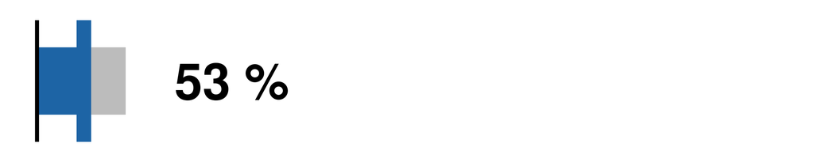

1.6

53 %

Données essentielles de la commande publique (DECP) - année 2020

- **Récapitulatif pour 2021**

type

acheteur

nombre de titulaires et part des TPME

nombre d'entreprises et part des TPME

nombre de marchés moyen par entreprise

part des entreprises locales

Lille

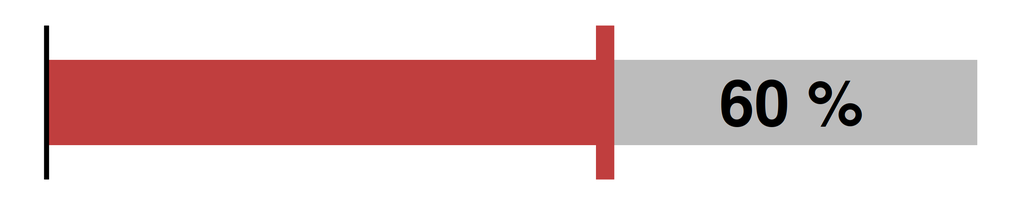

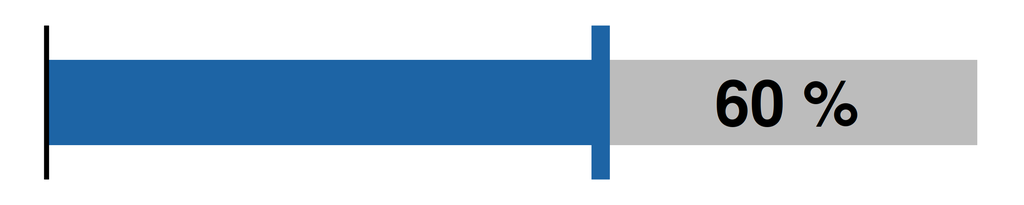

1.2

68 %

Roubaix

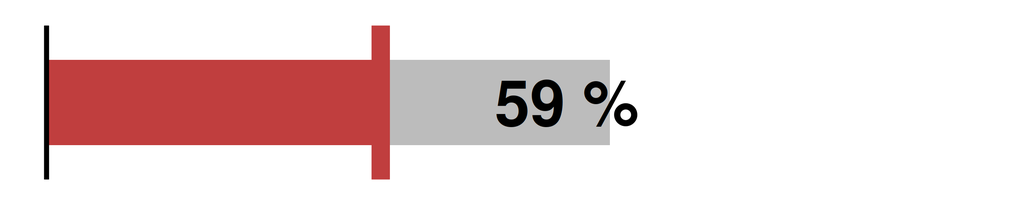

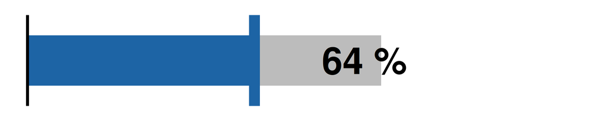

1.5

72 %

Ronchin

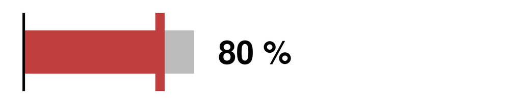

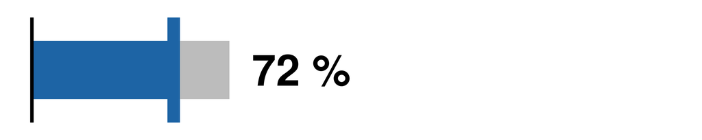

1.8

76 %

Lambersart

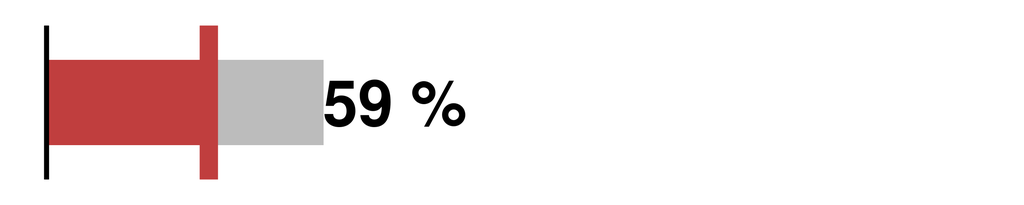

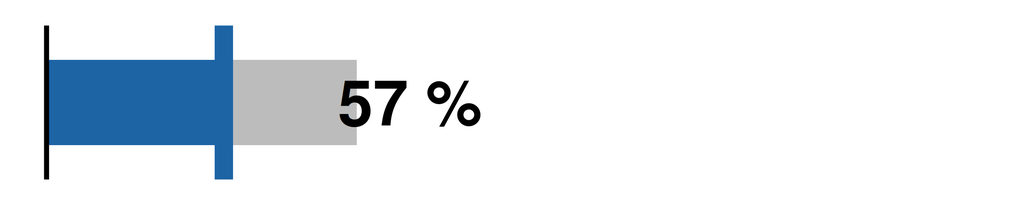

1.4

63 %

Haubourdin

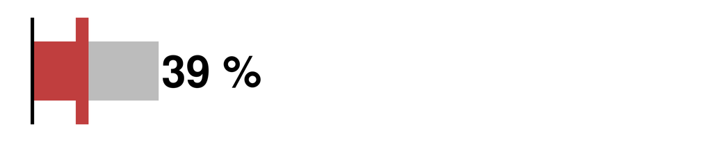

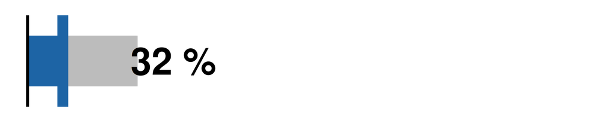

1.5

71 %

Croix

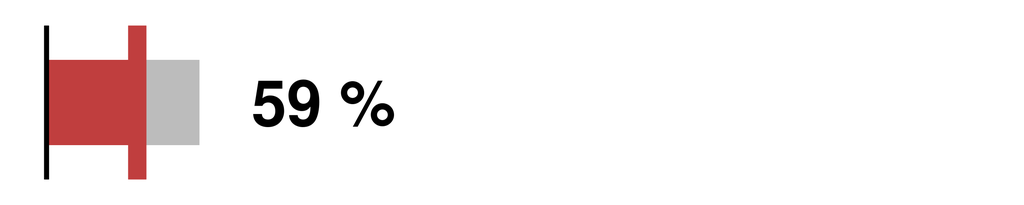

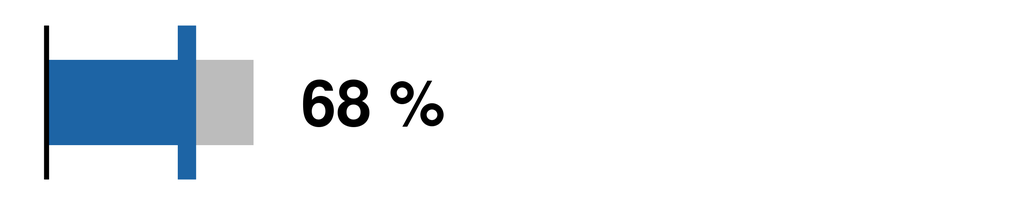

1.1

61 %

Données essentielles de la commande publique (DECP) - année 2021

## La méthodologie

Pour caractériser les titulaires de marchés publics de ces 6 acheteurs, nous procédons en plusieurs étapes ;

- nous récupérons les **données essentielles des marchés publics** de chaque acheteur ;
- nous récupérons les données du répertoire **SIRENE** (Système national d’identification et du répertoire des entreprises et de leurs établissements) ;
- nous rassemblons ces 2 jeux de données pour les analyser.

En croisant ces jeux de données, nous récoltons les informations nécessaires pour répondre à la problématique de ce cas d’usage, à savoir : **Quelle est la part des TPME dans les titulaires de marchés publics conclus par ma commune ? Ces titulaires sont-ils des entreprises locales ?**

La **première étape** consistant à trouver les données essentielles de la commune, nous avons épluché les profils d’acheteurs et les plateformes open data où pouvaient être publiées les données. En effet, chaque commune organise ses publications d’une manière différente : les données se trouvent pour certaines sur leur profil d’acheteur et/ou sur leur portail open data local, et pour d’autres sur la plateforme nationale ([data.gouv.fr](https://www.data.gouv.fr/fr/)).

La **deuxième étape**, quant à elle, portait sur les données récoltées par l’INSEE qui recense tous les établissements et unités légales françaises. Nous avons récupéré la base Sirene enrichie sur OpenDataSoft qui contient à la fois la typologie des entreprises et leur géolocalisation.

Enfin, la **troisième étape** consiste à assembler les données, pour ajouter aux données essentielles les informations recherchées. Ainsi, à partir du numéro SIRET, nous joignons les données et obtenons des DECP enrichies par les caractéristiques des entreprises titulaires des marchés.

## Les résultats

Les résultats sont présentés par acheteur et de manière visuelle : la première partie montre la part des **très petites, petites et moyennes entreprises** dans les titulaires de marchés publics, tandis que la seconde montre la **géolocalisation** des différentes entreprises.

### Ville de Lambersart

Nous avons récupéré les DECP de la **ville de Lambersart** sur le [profil d’acheteur AWS](https://www.marches-publics.info/Annonces/lister). La ville publie les données essentielles pour tous les marchés dont le montant est supérieur ou égal à 40.000 euros HT.

##### **Typologie des titulaires**

La première partie des résultats montre la part des **très petites entreprises** (TPE) et des **petites et moyennes entreprises** (PME) dans les titulaires de marchés publics, que nous regroupons sous le sigle “TPME”. Elle met aussi en lumière la part des entreprises de taille intermédiaire (ETI) et des grandes entreprises (GE). Nous nous sommes basés sur la définition des catégories d’entreprises donnée par l’[article 51 de la loi de modernisation de l’économie](https://www.economie.gouv.fr/cedef/definition-petites-et-moyennes-entreprises) (LME) :

- une **TPE** est une entreprise de moins de 10 salariés, avec un chiffre d’affaires ou un bilan inférieur à 2 millions d’euros ;
- une **PME** est une entreprise de moins de 250 salariés, avec un chiffre d’affaires inférieur à 50 millions d’euros ou un bilan inférieur à 43 millions d’euros ;
- une **ETI** est une entreprise de moins de 5000 salariés (hors PME), avec un chiffre d’affaires inférieur à 1.500 millions d’euros ou un bilan inférieur à 2.000 millions d’euros ;
- une **GE** est une entreprise qui ne peut pas être classée dans les catégories ci-dessus.

Nous présentons ainsi la répartition des catégories d’entreprises avec 2 niveaux de lecture :

- les **titulaires de marchés** à partir des DECP initiales, c’est-à-dire que l’entreprise titulaire apparaît autant de fois qu’elle a conclu un marché avec l’acheteur ;
- les **différentes entreprises** en ne prenant pas en compte le nombre de marchés conclus avec l’acheteur.

###### 2019

En 2019, la ville de Lambersart a conclu 118 marchés publics avec 134 titulaires correspondant à 77 entreprises différentes, soit une moyenne de 1.53 marché(s) par entreprise. Sur les 118 marchés publics conclus, 105 sont mono-attributaires et 13 sont multi-attributaires.

[interactive chart not shown]

Sur le graphique ci-dessus, on voit d’une part la typologie des titulaires des marchés et d’autre part celle des 77 opérateurs économiques différents de la ville de Lambersart.

- En raisonnant par **titulaire** : on voit que la part des TPME dans les titulaires de marchés publics est de 47.01% avec 63 titulaires ayant exécuté 59 marchés. Parmi les 71 titulaires restants, 34 sont des ETI (soit 25.37% des titulaires) ayant exécuté 34 marchés et 37 sont des GE (27.61%) ayant exécuté 37 marchés.
- En raisonnant par **entreprise différente** : on voit que la part des TPME est de 62.34% avec 48 entreprises différentes. Parmi les 29 entreprises restantes, 17 sont des ETI (22.08%) et 12 sont des GE (15.58%).

###### 2020

En 2020, la ville de Lambersart a conclu 68 marchés publics avec 77 titulaires correspondant à 44 entreprises différentes, soit une moyenne de 1.55 marché(s) par entreprise. Sur les 68 marchés publics conclus, 65 sont mono-attributaires et 3 sont multi-attributaires.

[interactive chart not shown]

De la même manière, nous pouvons regarder la typologie des titulaires et des différentes entreprises l’année suivante, soit en **2020**.

- En raisonnant par **titulaire** : on voit que la part des TPME dans les titulaires de marchés publics est de 37.66% avec 29 titulaires ayant exécuté 29 marchés. Parmi les 48 titulaires restants, 17 sont des ETI (soit 22.08% des titulaires) ayant exécuté 17 marchés, 29 sont des GE (37.66%) ayant exécuté 24 marchés, et pour 2 d’entre eux nous ne disposons pas de la catégorie d’entreprise (2.6% : donnée indisponible, associations, administrations…).
- En raisonnant par **entreprise différente** : on voit que la part des TPME est de 52.27% avec 23 entreprises différentes. Parmi les 21 entreprises restantes, 9 sont des ETI (20.45%), 10 sont des GE (22.73%) et pour 2 d’entre elles nous ne disposons pas de la catégorie d’entreprise (4.55% : donnée indisponible, associations, administrations…).

###### 2021

En 2021, la ville de Lambersart a conclu 58 marchés publics mono-attribués à 42 entreprises différentes, soit une moyenne de 1.38 marché(s) par entreprise.

[interactive chart not shown]

De la même manière, nous pouvons regarder la typologie des titulaires et des différentes entreprises l’année suivante, soit en **2021**.

- En raisonnant par **titulaire** : on voit que la part des TPME dans les titulaires de marchés publics est de 58.62% avec 34 titulaires. Parmi les 24 titulaires restants, 13 sont des ETI (soit 22.41% des titulaires), 9 sont des GE (15.52%), et pour 2 d’entre eux nous ne disposons pas de la catégorie d’entreprise (3.45% : donnée indisponible, associations, administrations…).
- En raisonnant par **entreprise différente** : on voit que la part des TPME est de 57.14% avec 24 entreprises différentes. Parmi les 18 entreprises restantes, 9 sont des ETI (21.43%), 7 sont des GE (16.67%) et pour 2 d’entre elles nous ne disposons pas de la catégorie d’entreprise (4.76% : donnée indisponible, associations, administrations…).

##### **Localisation des titulaires**

La seconde partie des résultats montre de manière visuelle la **géolocalisation** des entreprises titulaires des marchés publics de la ville. Nous préciserons aussi la répartition des entreprises selon leur localisation, en nous basant sur les critères suivants :

- sont **locales** toutes les entreprises situées dans le *département* de l’acheteur ;
- sont **régionales** toutes les entreprises situées dans la *région* de l’acheteur, mais hors de son *département* ;
- sont **nationales** toutes les autres entreprises titulaires.

La géolocalisation des entreprises est représentée par année sur une carte de la France, avec un code couleur reprenant la typologie des titulaires analysée en partie précédente :

- **vert** correspond aux *TPME* ;
- **orange** correspond aux *ETI* ;
- **rouge** correspond aux *GE* ;
- **gris** correspond aux entreprises pour lesquelles nous ne disposons pas de la typologie.

###### 2019

[interactive chart not shown]

Sur les 77 entreprises titulaires de marchés publics en 2019, nous avons récupéré la géolocalisation de 75 d’entre elles. Toutefois, nous n’avons pas pu récupérer la géolocalisation de 2 d’entre elles, ce qui peut être dû à un numéro de SIRET invalide, et/ou qui n’est pas recensé dans la base **Sirene** de l’INSEE.

Parmi les titulaires géolocalisés sur la carte, nous avons :

- 44 entreprises **locales** soit 58.67% (département du Nord), dont 28 TPME ;
- 8 entreprises **régionales** soit 10.67% (région Hauts-de-France), dont 3 TPME ;
- 23 entreprises **nationales** soit 30.67% (entreprises localisées hors région Hauts-de-France), dont 16 TPME.

###### 2020

[interactive chart not shown]

Sur les 44 entreprises titulaires de marchés publics en 2020, nous avons récupéré la géolocalisation de 41 d’entre elles.

Parmi ces titulaires, nous avons :

- 21 entreprises **locales** soit 51.22%, dont 15 TPME ;
- 4 entreprises **régionales** soit 9.76%, dont 3 TPME ;
- 16 entreprises **nationales** soit 39.02%, dont 4 TPME.

###### 2021

[interactive chart not shown]

Sur les 42 entreprises titulaires de marchés publics en 2021, nous avons récupéré la géolocalisation de 41 d’entre elles.

Parmi ces titulaires, nous avons :

- 26 entreprises **locales** soit 63.41%, dont 17 TPME ;
- 5 entreprises **régionales** soit 12.2%, dont 3 TPME ;
- 10 entreprises **nationales** soit 24.39%, dont 4 TPME.

La part des entreprises locales dans les titulaires de marchés publics de la ville est ainsi plus élevée en 2021.

### Ville de Haubourdin

Nous avons récupéré les DECP de la **ville de Haubourdin** sur le [profil d’acheteur marchespublics596280](https://marchespublics596280.fr/?page=Entreprise.EntrepriseRechercherListeMarches&search), mutualisé pour le département du Nord. La ville publie les données essentielles pour tous les marchés dont le montant est supérieur ou égal à 40.000 euros HT.

##### **Typologie des titulaires**

La première partie des résultats montre la part des **très petites entreprises** (TPE) et des **petites et moyennes entreprises** (PME) dans les titulaires de marchés publics, que nous regroupons sous le sigle “TPME”. Elle met aussi en lumière la part des entreprises de taille intermédiaire (ETI) et des grandes entreprises (GE). Nous nous sommes basés sur la définition des catégories d’entreprises donnée par l’[article 51 de la loi de modernisation de l’économie](https://www.economie.gouv.fr/cedef/definition-petites-et-moyennes-entreprises) (LME) :

- une **TPE** est une entreprise de moins de 10 salariés, avec un chiffre d’affaires ou un bilan inférieur à 2 millions d’euros ;
- une **PME** est une entreprise de moins de 250 salariés, avec un chiffre d’affaires inférieur à 50 millions d’euros ou un bilan inférieur à 43 millions d’euros ;
- une **ETI** est une entreprise de moins de 5000 salariés (hors PME), avec un chiffre d’affaires inférieur à 1.500 millions d’euros ou un bilan inférieur à 2.000 millions d’euros ;
- une **GE** est une entreprise qui ne peut pas être classée dans les catégories ci-dessus.

Nous présentons ainsi la répartition des catégories d’entreprises avec 2 niveaux de lecture :

- les **titulaires de marchés** à partir des DECP initiales, c’est-à-dire que l’entreprise titulaire apparaît autant de fois qu’elle a conclu un marché avec l’acheteur ;
- les **différentes entreprises** en ne prenant pas en compte le nombre de marchés conclus avec l’acheteur.

###### 2019

En 2019, la ville de Haubourdin a conclu 31 marchés publics mono-attribués à 22 entreprises différentes, soit une moyenne de 1.41 marché(s) par entreprise.

[interactive chart not shown]

Sur le graphique ci-dessus, on voit d’une part la typologie des titulaires des marchés et d’autre part celle des 22 opérateurs économiques différents de la ville de Haubourdin.

- En raisonnant par **titulaire** : on voit que la part des TPME dans les titulaires de marchés publics est de 64.52% avec 20 titulaires. Les 11 titulaires restants sont des ETI (soit 35.48% des titulaires).
- En raisonnant par **entreprise différente** : on voit que la part des TPME est de 63.64% avec 14 entreprises différentes. Les 8 entreprises restantes sont des ETI (36.36%).

###### 2020

En 2020, la ville de Haubourdin a conclu 27 marchés publics mono-attribués à 17 entreprises différentes, soit une moyenne de 1.59 marché(s) par entreprise.

[interactive chart not shown]

De la même manière, nous pouvons regarder la typologie des titulaires et des différentes entreprises l’année suivante, soit en **2020**.

- En raisonnant par **titulaire** : on voit que la part des TPME dans les titulaires de marchés publics est de 55.56% avec 15 titulaires. Parmi les 12 titulaires restants, 6 sont des ETI (soit 22.22% des titulaires), et 6 sont des GE (22.22%).
- En raisonnant par **entreprise différente** : on voit que la part des TPME est de 52.94% avec 9 entreprises différentes. Parmi les 8 entreprises restantes, 4 sont des ETI (23.53%), et 4 sont des GE (23.53%).

###### 2021

En 2021, la ville de Haubourdin a conclu 38 marchés publics mono-attribués à 25 entreprises différentes, soit une moyenne de 1.52 marché(s) par entreprise.

[interactive chart not shown]

De la même manière, nous pouvons regarder la typologie des titulaires et des différentes entreprises l’année suivante, soit en **2021**.

- En raisonnant par **titulaire** : on voit que la part des TPME dans les titulaires de marchés publics est de 39.47% avec 15 titulaires. Parmi les 23 titulaires restants, 17 sont des ETI (soit 44.74% des titulaires), 1 est une GE (2.63%), et pour 5 d’entre eux nous ne disposons pas de la catégorie d’entreprise (13.16% : donnée indisponible, associations, administrations…).
- En raisonnant par **entreprise différente** : on voit que la part des TPME est de 32% avec 8 entreprises différentes. Parmi les 17 entreprises restantes, 12 sont des ETI (48%), 1 est une GE (4%) et pour 4 d’entre elles nous ne disposons pas de la catégorie d’entreprise (16% : donnée indisponible, associations, administrations…).

##### **Localisation des titulaires**

La seconde partie des résultats montre de manière visuelle la **géolocalisation** des entreprises titulaires des marchés publics de la ville. Nous préciserons aussi la répartition des entreprises selon leur localisation, en nous basant sur les critères suivants :

- sont **locales** toutes les entreprises situées dans le *département* de l’acheteur ;
- sont **régionales** toutes les entreprises situées dans la *région* de l’acheteur, mais hors de son *département* ;
- sont **nationales** toutes les autres entreprises titulaires.

La géolocalisation des entreprises est représentée par année sur une carte de la France, avec un code couleur reprenant la typologie des titulaires analysée en partie précédente :

- **vert** correspond aux *TPME* ;
- **orange** correspond aux *ETI* ;
- **rouge** correspond aux *GE* ;
- **gris** correspond aux entreprises pour lesquelles nous ne disposons pas de la typologie.

###### 2019

[interactive chart not shown]

En 2019, nous avons récupéré la géolocalisation de tous les titulaires de marchés publics, soit 22 entreprises.

Pour ces titulaires géolocalisés sur la carte, nous avons :

- 13 entreprises **locales** soit 59.09% (département du Nord), dont 8 TPME ;
- 1 entreprise **régionale** soit 4.55% (région Hauts-de-France), qui est une TPME ;
- 8 entreprises **nationales** soit 36.36% (entreprises localisées hors région Hauts-de-France), dont 5 TPME.

###### 2020

[interactive chart not shown]

En 2020, nous avons récupéré la géolocalisation de tous les titulaires de marchés publics, soit 17 entreprises.

Pour ces titulaires, nous avons :

- 9 entreprises **locales** soit 52.94%, dont 5 TPME ;
- 8 entreprises **nationales** soit 47.06%, dont 4 TPME.

###### 2021

[interactive chart not shown]

Sur les 25 entreprises titulaires de marchés publics en 2021, nous avons récupéré la géolocalisation de 24 d’entre elles.

Parmi ces titulaires, nous avons :

- 17 entreprises **locales** soit 70.83%, dont 6 TPME ;
- 1 entreprise **régionale** soit 4.17%, qui n’est pas une TPME ;
- 6 entreprises **nationales** soit 25%, dont 2 TPME.

La part des entreprises locales dans les titulaires de marchés publics de la ville est ainsi plus élevée en 2021.

### Ville de Croix

Nous avons récupéré les DECP de la **ville de Croix** sur le [profil d’acheteur marches-securises](https://marches-securises.fr/entreprise/?module=an_prec). La ville publie les données essentielles pour tous les marchés dont le montant est supérieur ou égal à 25.000 euros HT.

##### **Typologie des titulaires**

La première partie des résultats montre la part des **très petites entreprises** (TPE) et des **petites et moyennes entreprises** (PME) dans les titulaires de marchés publics, que nous regroupons sous le sigle “TPME”. Elle met aussi en lumière la part des entreprises de taille intermédiaire (ETI) et des grandes entreprises (GE). Nous nous sommes basés sur la définition des catégories d’entreprises donnée par l’[article 51 de la loi de modernisation de l’économie](https://www.economie.gouv.fr/cedef/definition-petites-et-moyennes-entreprises) (LME) :

- une **TPE** est une entreprise de moins de 10 salariés, avec un chiffre d’affaires ou un bilan inférieur à 2 millions d’euros ;
- une **PME** est une entreprise de moins de 250 salariés, avec un chiffre d’affaires inférieur à 50 millions d’euros ou un bilan inférieur à 43 millions d’euros ;
- une **ETI** est une entreprise de moins de 5000 salariés (hors PME), avec un chiffre d’affaires inférieur à 1.500 millions d’euros ou un bilan inférieur à 2.000 millions d’euros ;
- une **GE** est une entreprise qui ne peut pas être classée dans les catégories ci-dessus.

Nous présentons ainsi la répartition des catégories d’entreprises avec 2 niveaux de lecture :

- les **titulaires de marchés** à partir des DECP initiales, c’est-à-dire que l’entreprise titulaire apparaît autant de fois qu’elle a conclu un marché avec l’acheteur ;
- les **différentes entreprises** en ne prenant pas en compte le nombre de marchés conclus avec l’acheteur.

###### 2019

En 2019, la ville de Croix a conclu 35 marchés publics avec 86 titulaires correspondant à 54 entreprises différentes, soit une moyenne de 0.65 marché(s) par entreprise. Sur les 35 marchés publics conclus, 28 sont mono-attributaires et 7 sont multi-attributaires.

[interactive chart not shown]

Sur le graphique ci-dessus, on voit d’une part la typologie des titulaires des marchés et d’autre part celle des 54 opérateurs économiques différents de la ville de Croix.

- En raisonnant par **titulaire** : on voit que la part des TPME dans les titulaires de marchés publics est de 61.63% avec 53 titulaires ayant exécuté 24 marchés. Parmi les 33 titulaires restants, 11 sont des ETI (soit 12.79% des titulaires) ayant exécuté 5 marchés, 21 sont des GE (24.42%) ayant exécuté 11 marchés, et pour 1 d’entre eux nous ne disposons pas de la catégorie d’entreprise (1.16% : donnée indisponible, associations, administrations…).
- En raisonnant par **entreprise différente** : on voit que la part des TPME est de 70.37% avec 38 entreprises différentes. Parmi les 16 entreprises restantes, 7 sont des ETI (12.96%), 8 sont des GE (14.81%), et pour 1 d’entre eux nous ne disposons pas de la catégorie d’entreprise (1.85% : donnée indisponible, associations, administrations…).

###### 2020

En 2020, la ville de Croix a conclu 46 marchés publics avec 58 titulaires correspondant à 40 entreprises différentes, soit une moyenne de 1.15 marché(s) par entreprise. Sur les 46 marchés publics conclus, 40 sont mono-attributaires et 6 sont multi-attributaires.

[interactive chart not shown]

De la même manière, nous pouvons regarder la typologie des titulaires et des différentes entreprises l’année suivante, soit en **2020**.

- En raisonnant par **titulaire** : on voit que la part des TPME dans les titulaires de marchés publics est de 48.28% avec 28 titulaires ayant exécuté 21 marchés. Parmi les 30 titulaires restants, 21 sont des ETI (soit 36.21% des titulaires) ayant exécuté 18 marchés, 7 sont des GE (12.07%) ayant exécuté 7 marchés, et pour 2 d’entre eux nous ne disposons pas de la catégorie d’entreprise (3.45% : donnée indisponible, associations, administrations…).
- En raisonnant par **entreprise différente** : on voit que la part des TPME est de 50% avec 20 entreprises différentes. Parmi les 20 entreprises restantes, 12 sont des ETI (30%), 6 sont des GE (15%) et pour 2 d’entre elles nous ne disposons pas de la catégorie d’entreprise (5% : donnée indisponible, associations, administrations…).

###### 2021

En 2021, la ville de Croix a conclu 30 marchés publics avec 32 titulaires correspondant à 28 entreprises différentes, soit une moyenne de 1.07 marché(s) par entreprise. Sur les 30 marchés publics conclus, 28 sont mono-attributaires et 2 sont multi-attributaires.

[interactive chart not shown]

De la même manière, nous pouvons regarder la typologie des titulaires et des différentes entreprises l’année suivante, soit en **2021**.

- En raisonnant par **titulaire** : on voit que la part des TPME dans les titulaires de marchés publics est de 59.38% avec 19 titulaires ayant exécuté 19 marchés. Parmi les 13 titulaires restants, 10 sont des ETI (soit 31.25% des titulaires) ayant exécuté 9 marchés, 2 sont des GE (6.25%) ayant exécuté 2 marchés, et pour 1 d’entre eux nous ne disposons pas de la catégorie d’entreprise (3.12% : donnée indisponible, associations, administrations…).
- En raisonnant par **entreprise différente** : on voit que la part des TPME est de 67.86% avec 19 entreprises différentes. Parmi les 9 entreprises restantes, 6 sont des ETI (21.43%), 2 sont des GE (7.14%) et pour 1 d’entre elles nous ne disposons pas de la catégorie d’entreprise (3.57% : donnée indisponible, associations, administrations…).

##### **Localisation des titulaires**

La seconde partie des résultats montre de manière visuelle la **géolocalisation** des entreprises titulaires des marchés publics de la ville. Nous préciserons aussi la répartition des entreprises selon leur localisation, en nous basant sur les critères suivants :

- sont **locales** toutes les entreprises situées dans le *département* de l’acheteur ;
- sont **régionales** toutes les entreprises situées dans la *région* de l’acheteur, mais hors de son *département* ;
- sont **nationales** toutes les autres entreprises titulaires.

La géolocalisation des entreprises est représentée par année sur une carte de la France, avec un code couleur reprenant la typologie des titulaires analysée en partie précédente :

- **vert** correspond aux *TPME* ;
- **orange** correspond aux *ETI* ;
- **rouge** correspond aux *GE* ;
- **gris** correspond aux entreprises pour lesquelles nous ne disposons pas de la typologie.

###### 2019

[interactive chart not shown]

Sur les 54 entreprises titulaires de marchés publics en 2019, nous avons récupéré la géolocalisation de 52 d’entre elles. Toutefois, nous n’avons pas pu récupérer la géolocalisation de 2 d’entre elles, ce qui peut être dû à un numéro de SIRET invalide, et/ou qui n’est pas recensé dans la base **Sirene** de l’INSEE.

Parmi les titulaires géolocalisés sur la carte, nous avons :

- 39 entreprises **locales** soit 75% (département du Nord), dont 27 TPME ;
- 3 entreprises **régionales** soit 5.77% (région Hauts-de-France), dont 3 TPME ;
- 10 entreprises **nationales** soit 19.23% (entreprises localisées hors région Hauts-de-France), dont 8 TPME.

###### 2020

[interactive chart not shown]

Sur les 40 entreprises titulaires de marchés publics en 2020, nous avons récupéré la géolocalisation de 38 d’entre elles.

Parmi ces titulaires, nous avons :

- 24 entreprises **locales** soit 63.16%, dont 14 TPME ;
- 5 entreprises **régionales** soit 13.16%, dont 1 TPME ;
- 9 entreprises **nationales** soit 23.68%, dont 5 TPME.

###### 2021

[interactive chart not shown]

Sur les 28 entreprises titulaires de marchés publics en 2021, nous avons récupéré la géolocalisation de 28 d’entre elles.

Parmi ces titulaires, nous avons :

- 17 entreprises **locales** soit 60.71%, dont 11 TPME ;
- 2 entreprises **régionales** soit 7.14%, dont 2 TPME ;
- 9 entreprises **nationales** soit 32.14%, dont 6 TPME.

La part des entreprises locales dans les titulaires de marchés publics de la ville est ainsi plus élevée en 2019.

### Ville de Lille

##### **Typologie des titulaires**

La première partie des résultats montre la part des **très petites entreprises** (TPE) et des **petites et moyennes entreprises** (PME) dans les titulaires de marchés publics, que nous regroupons sous le sigle “TPME”. Elle met aussi en lumière la part des entreprises de taille intermédiaire (ETI) et des grandes entreprises (GE). Nous nous sommes basés sur la définition des catégories d’entreprises donnée par l’[article 51 de la loi de modernisation de l’économie](https://www.economie.gouv.fr/cedef/definition-petites-et-moyennes-entreprises) (LME) :

- une **TPE** est une entreprise de moins de 10 salariés, avec un chiffre d’affaires ou un bilan inférieur à 2 millions d’euros ;
- une **PME** est une entreprise de moins de 250 salariés, avec un chiffre d’affaires inférieur à 50 millions d’euros ou un bilan inférieur à 43 millions d’euros ;
- une **ETI** est une entreprise de moins de 5000 salariés (hors PME), avec un chiffre d’affaires inférieur à 1.500 millions d’euros ou un bilan inférieur à 2.000 millions d’euros ;
- une **GE** est une entreprise qui ne peut pas être classée dans les catégories ci-dessus.

Nous présentons ainsi la répartition des catégories d’entreprises avec 2 niveaux de lecture :

- les **titulaires de marchés** à partir des DECP initiales, c’est-à-dire que l’entreprise titulaire apparaît autant de fois qu’elle a conclu un marché avec l’acheteur ;
- les **différentes entreprises** en ne prenant pas en compte le nombre de marchés conclus avec l’acheteur.

###### 2019

En 2019, la ville de Lille a conclu 67 marchés publics avec 94 titulaires correspondant à 65 entreprises différentes, soit une moyenne de 1.03 marché(s) par entreprise. Sur les 67 marchés publics conclus, 60 sont mono-attributaires et 7 sont multi-attributaires.

[interactive chart not shown]

Sur le graphique ci-dessus, on voit d’une part la typologie des titulaires des marchés et d’autre part celle des 65 opérateurs économiques différents de la ville de Lille.

- En raisonnant par **titulaire** : on voit que la part des TPME dans les titulaires de marchés publics est de 80.85% avec 76 titulaires ayant exécuté 54 marchés. Parmi les 18 titulaires restants, 11 sont des ETI (soit 11.7% des titulaires) ayant exécuté 10 marchés, 6 sont des GE (6.38%) ayant exécuté 6 marchés, et pour 1 d’entre elles nous ne disposons pas de la catégorie d’entreprise (1.06% : donnée indisponible, associations, administrations…).
- En raisonnant par **entreprise différente** : on voit que la part des TPME est de 78.46% avec 51 entreprises différentes. Parmi les 14 entreprises restantes, 9 sont des ETI (13.85%), 4 sont des GE (6.15%) et pour 1 d’entre elles nous ne disposons pas de la catégorie d’entreprise (1.54% : donnée indisponible, associations, administrations…).

###### 2020

En 2020, la ville de Lille a conclu 191 marchés publics avec 226 titulaires correspondant à 142 entreprises différentes, soit une moyenne de 1.35 marché(s) par entreprise. Sur les 191 marchés publics conclus, 173 sont mono-attributaires et 18 sont multi-attributaires.

[interactive chart not shown]

De la même manière, nous pouvons regarder la typologie des titulaires et des différentes entreprises l’année suivante, soit en **2020**.

- En raisonnant par **titulaire** : on voit que la part des TPME dans les titulaires de marchés publics est de 68.58% avec 155 titulaires ayant exécuté 133 marchés. Parmi les 71 titulaires restants, 35 sont des ETI (soit 15.49% des titulaires) ayant exécuté 34 marchés, 33 sont des GE (14.6%) ayant exécuté 30 marchés, et pour 3 d’entre eux nous ne disposons pas de la catégorie d’entreprise (1.33% : donnée indisponible, associations, administrations…).
- En raisonnant par **entreprise différente** : on voit que la part des TPME est de 69.01% avec 98 entreprises différentes. Parmi les 44 entreprises restantes, 23 sont des ETI (16.2%), 18 sont des GE (12.68%) et pour 3 d’entre elles nous ne disposons pas de la catégorie d’entreprise (2.11% : donnée indisponible, associations, administrations…).

###### 2021

En 2021, la ville de Lille a conclu 147 marchés publics avec 195 titulaires correspondant à 126 entreprises différentes, soit une moyenne de 1.17 marché(s) par entreprise. Sur les 147 marchés publics conclus, 127 sont mono-attributaires et 20 sont multi-attributaires.

[interactive chart not shown]

De la même manière, nous pouvons regarder la typologie des titulaires et des différentes entreprises l’année suivante, soit en **2021**.

- En raisonnant par **titulaire** : on voit que la part des TPME dans les titulaires de marchés publics est de 60% avec 117 titulaires ayant exécuté 93 marchés. Parmi les 78 titulaires restants, 54 sont des ETI (soit 27.69% des titulaires) ayant exécuté 49 marchés, 19 sont des GE (9.74%) ayant exécuté 16 marchés, et pour 5 d’entre eux nous ne disposons pas de la catégorie d’entreprise (2.56% : donnée indisponible, associations, administrations…).
- En raisonnant par **entreprise différente** : on voit que la part des TPME est de 59.52% avec 75 entreprises différentes. Parmi les 51 entreprises restantes, 35 sont des ETI (27.78%), 12 sont des GE (9.52%) et pour 4 d’entre elles nous ne disposons pas de la catégorie d’entreprise (3.17% : donnée indisponible, associations, administrations…).

##### **Localisation des titulaires**

La seconde partie des résultats montre de manière visuelle la **géolocalisation** des entreprises titulaires des marchés publics de la ville. Nous préciserons aussi la répartition des entreprises selon leur localisation, en nous basant sur les critères suivants :

- sont **locales** toutes les entreprises situées dans le *département* de l’acheteur ;
- sont **régionales** toutes les entreprises situées dans la *région* de l’acheteur, mais hors de son *département* ;
- sont **nationales** toutes les autres entreprises titulaires.

La géolocalisation des entreprises est représentée par année sur une carte de la France, avec un code couleur reprenant la typologie des titulaires analysée en partie précédente :

- **vert** correspond aux *TPME* ;
- **orange** correspond aux *ETI* ;
- **rouge** correspond aux *GE* ;
- **gris** correspond aux entreprises pour lesquelles nous ne disposons pas de la typologie.

###### 2019

[interactive chart not shown]

Sur les 65 entreprises titulaires de marchés publics en 2019, nous avons récupéré la géolocalisation de 64 d’entre elles. Toutefois, nous n’avons pas pu récupérer la géolocalisation de 1 d’entre elles, ce qui peut être dû à un numéro de SIRET invalide, et/ou qui n’est pas recensé dans la base **Sirene** de l’INSEE.

Parmi les titulaires géolocalisés sur la carte, nous avons :

- 46 entreprises **locales** soit 71.88% (département du Nord), dont 36 TPME ;
- 12 entreprises **régionales** soit 18.75% (région Hauts-de-France), dont 9 TPME ;
- 6 entreprises **nationales** soit 9.38% (entreprises localisées hors région Hauts-de-France), dont 6 TPME.

###### 2020

[interactive chart not shown]

Sur les 142 entreprises titulaires de marchés publics en 2020, nous avons récupéré la géolocalisation de 138 d’entre elles.

Parmi ces titulaires, nous avons :

- 90 entreprises **locales** soit 65.22%, dont 68 TPME ;
- 15 entreprises **régionales** soit 10.87%, dont 9 TPME ;
- 33 entreprises **nationales** soit 23.91%, dont 20 TPME.

###### 2021

[interactive chart not shown]

Sur les 126 entreprises titulaires de marchés publics en 2021, nous avons récupéré la géolocalisation de 120 d’entre elles.

Parmi ces titulaires, nous avons :

- 81 entreprises **locales** soit 67.5%, dont 53 TPME ;
- 8 entreprises **régionales** soit 6.67%, dont 3 TPME ;
- 31 entreprises **nationales** soit 25.83%, dont 19 TPME.

La part des entreprises locales dans les titulaires de marchés publics de la ville est ainsi plus élevée en 2019.

### Ville de Roubaix

##### **Typologie des titulaires**

La première partie des résultats montre la part des **très petites entreprises** (TPE) et des **petites et moyennes entreprises** (PME) dans les titulaires de marchés publics, que nous regroupons sous le sigle “TPME”. Elle met aussi en lumière la part des entreprises de taille intermédiaire (ETI) et des grandes entreprises (GE). Nous nous sommes basés sur la définition des catégories d’entreprises donnée par l’[article 51 de la loi de modernisation de l’économie](https://www.economie.gouv.fr/cedef/definition-petites-et-moyennes-entreprises) (LME) :

- une **TPE** est une entreprise de moins de 10 salariés, avec un chiffre d’affaires ou un bilan inférieur à 2 millions d’euros ;
- une **PME** est une entreprise de moins de 250 salariés, avec un chiffre d’affaires inférieur à 50 millions d’euros ou un bilan inférieur à 43 millions d’euros ;
- une **ETI** est une entreprise de moins de 5000 salariés (hors PME), avec un chiffre d’affaires inférieur à 1.500 millions d’euros ou un bilan inférieur à 2.000 millions d’euros ;
- une **GE** est une entreprise qui ne peut pas être classée dans les catégories ci-dessus.

Nous présentons ainsi la répartition des catégories d’entreprises avec 2 niveaux de lecture :

- les **titulaires de marchés** à partir des DECP initiales, c’est-à-dire que l’entreprise titulaire apparaît autant de fois qu’elle a conclu un marché avec l’acheteur ;
- les **différentes entreprises** en ne prenant pas en compte le nombre de marchés conclus avec l’acheteur.

###### 2019

En 2019, la ville de Roubaix a conclu 59 marchés publics mono-attribués à 47 entreprises différentes, soit une moyenne de 1.26 marché(s) par entreprise.

[interactive chart not shown]

Sur le graphique ci-dessus, on voit d’une part la typologie des titulaires des marchés et d’autre part celle des 47 opérateurs économiques différents de la ville de Roubaix.

- En raisonnant par **titulaire** : on voit que la part des TPME dans les titulaires de marchés publics est de 59.32% avec 35 titulaires. Parmi les 24 titulaires restants, 15 sont des ETI (soit 25.42% des titulaires), 5 sont des GE (8.47%), et pour 4 d’entre eux nous ne disposons pas de la catégorie d’entreprise (6.78% : donnée indisponible, associations, administrations…).
- En raisonnant par **entreprise différente** : on voit que la part des TPME est de 57.45% avec 27 entreprises différentes. Parmi les 20 entreprises restantes, 12 sont des ETI (25.53%), 5 sont des GE (10.64%) et pour 3 d’entre elles nous ne disposons pas de la catégorie d’entreprise (6.38% : donnée indisponible, associations, administrations…).

###### 2020

En 2020, la ville de Roubaix a conclu 122 marchés publics mono-attribués à 76 entreprises différentes, soit une moyenne de 1.61 marché(s) par entreprise.

[interactive chart not shown]

De la même manière, nous pouvons regarder la typologie des titulaires et des différentes entreprises l’année suivante, soit en **2020**.

- En raisonnant par **titulaire** : on voit que la part des TPME dans les titulaires de marchés publics est de 77.05% avec 94 titulaires. Parmi les 28 titulaires restants, 18 sont des ETI (soit 14.75% des titulaires), 7 sont des GE (5.74%), et pour 3 d’entre eux nous ne disposons pas de la catégorie d’entreprise (2.46% : donnée indisponible, associations, administrations…).
- En raisonnant par **entreprise différente** : on voit que la part des TPME est de 75% avec 57 entreprises différentes. Parmi les 19 entreprises restantes, 11 sont des ETI (14.47%), 5 sont des GE (6.58%) et pour 3 d’entre elles nous ne disposons pas de la catégorie d’entreprise (3.95% : donnée indisponible, associations, administrations…).

###### 2021

En 2021, la ville de Roubaix a conclu 118 marchés publics mono-attribués à 81 entreprises différentes, soit une moyenne de 1.46 marché(s) par entreprise.

[interactive chart not shown]

De la même manière, nous pouvons regarder la typologie des titulaires et des différentes entreprises l’année suivante, soit en **2021**.

- En raisonnant par **titulaire** : on voit que la part des TPME dans les titulaires de marchés publics est de 59.32% avec 70 titulaires. Parmi les 48 titulaires restants, 35 sont des ETI (soit 29.66% des titulaires), 8 sont des GE (6.78%), et pour 5 d’entre eux nous ne disposons pas de la catégorie d’entreprise (4.24% : donnée indisponible, associations, administrations…).
- En raisonnant par **entreprise différente** : on voit que la part des TPME est de 64.2% avec 52 entreprises différentes. Parmi les 29 entreprises restantes, 17 sont des ETI (20.99%), 7 sont des GE (8.64%) et pour 5 d’entre elles nous ne disposons pas de la catégorie d’entreprise (6.17% : donnée indisponible, associations, administrations…).

##### **Localisation des titulaires**

La seconde partie des résultats montre de manière visuelle la **géolocalisation** des entreprises titulaires des marchés publics de la ville. Nous préciserons aussi la répartition des entreprises selon leur localisation, en nous basant sur les critères suivants :

- sont **locales** toutes les entreprises situées dans le *département* de l’acheteur ;
- sont **régionales** toutes les entreprises situées dans la *région* de l’acheteur, mais hors de son *département* ;
- sont **nationales** toutes les autres entreprises titulaires.

La géolocalisation des entreprises est représentée par année sur une carte de la France, avec un code couleur reprenant la typologie des titulaires analysée en partie précédente :

- **vert** correspond aux *TPME* ;
- **orange** correspond aux *ETI* ;
- **rouge** correspond aux *GE* ;
- **gris** correspond aux entreprises pour lesquelles nous ne disposons pas de la typologie.

###### 2019

[interactive chart not shown]

Sur les 47 entreprises titulaires de marchés publics en 2019, nous avons récupéré la géolocalisation de 44 d’entre elles. Toutefois, nous n’avons pas pu récupérer la géolocalisation de 3 d’entre elles, ce qui peut être dû à un numéro de SIRET invalide, et/ou qui n’est pas recensé dans la base **Sirene** de l’INSEE.

Parmi les titulaires géolocalisés sur la carte, nous avons :

- 30 entreprises **locales** soit 68.18% (département du Nord), dont 20 TPME ;
- 4 entreprises **régionales** soit 9.09% (région Hauts-de-France), dont 3 TPME ;
- 10 entreprises **nationales** soit 22.73% (entreprises localisées hors région Hauts-de-France), dont 4 TPME.

###### 2020

[interactive chart not shown]

Sur les 76 entreprises titulaires de marchés publics en 2020, nous avons récupéré la géolocalisation de 71 d’entre elles.

Parmi ces titulaires, nous avons :

- 52 entreprises **locales** soit 73.24%, dont 43 TPME ;
- 4 entreprises **régionales** soit 5.63%, dont 3 TPME ;
- 15 entreprises **nationales** soit 21.13%, dont 11 TPME.

###### 2021

[interactive chart not shown]

Sur les 81 entreprises titulaires de marchés publics en 2021, nous avons récupéré la géolocalisation de 76 d’entre elles.

Parmi ces titulaires, nous avons :

- 55 entreprises **locales** soit 72.37%, dont 38 TPME ;
- 7 entreprises **régionales** soit 9.21%, dont 5 TPME ;
- 14 entreprises **nationales** soit 18.42%, dont 8 TPME.

La part des entreprises locales dans les titulaires de marchés publics de la ville est ainsi plus élevée en 2020.

### Ville de Ronchin

##### **Typologie des titulaires**

La première partie des résultats montre la part des **très petites entreprises** (TPE) et des **petites et moyennes entreprises** (PME) dans les titulaires de marchés publics, que nous regroupons sous le sigle “TPME”. Elle met aussi en lumière la part des entreprises de taille intermédiaire (ETI) et des grandes entreprises (GE). Nous nous sommes basés sur la définition des catégories d’entreprises donnée par l’[article 51 de la loi de modernisation de l’économie](https://www.economie.gouv.fr/cedef/definition-petites-et-moyennes-entreprises) (LME) :

- une **TPE** est une entreprise de moins de 10 salariés, avec un chiffre d’affaires ou un bilan inférieur à 2 millions d’euros ;
- une **PME** est une entreprise de moins de 250 salariés, avec un chiffre d’affaires inférieur à 50 millions d’euros ou un bilan inférieur à 43 millions d’euros ;
- une **ETI** est une entreprise de moins de 5000 salariés (hors PME), avec un chiffre d’affaires inférieur à 1.500 millions d’euros ou un bilan inférieur à 2.000 millions d’euros ;
- une **GE** est une entreprise qui ne peut pas être classée dans les catégories ci-dessus.

Nous présentons ainsi la répartition des catégories d’entreprises avec 2 niveaux de lecture :

- les **titulaires de marchés** à partir des DECP initiales, c’est-à-dire que l’entreprise titulaire apparaît autant de fois qu’elle a conclu un marché avec l’acheteur ;
- les **différentes entreprises** en ne prenant pas en compte le nombre de marchés conclus avec l’acheteur.

###### 2019

En 2019, la ville de Ronchin a conclu 72 marchés publics mono-attribués à 48 entreprises différentes, soit une moyenne de 1.5 marché(s) par entreprise.

[interactive chart not shown]

Sur le graphique ci-dessus, on voit d’une part la typologie des titulaires des marchés et d’autre part celle des 48 opérateurs économiques différents de la ville de Ronchin.

- En raisonnant par **titulaire** : on voit que la part des TPME dans les titulaires de marchés publics est de 77.78% avec 56 titulaires. Parmi les 16 titulaires restants, 12 sont des ETI (soit 16.67% des titulaires) et 4 sont des GE (5.56%).
- En raisonnant par **entreprise différente** : on voit que la part des TPME est de 72.92% avec 35 entreprises différentes. Parmi les 13 entreprises restantes, 10 sont des ETI (20.83%) et 3 sont des GE (6.25%).

###### 2020

En 2020, la ville de Ronchin a conclu 43 marchés publics mono-attribués à 35 entreprises différentes, soit une moyenne de 1.23 marché(s) par entreprise.

[interactive chart not shown]

De la même manière, nous pouvons regarder la typologie des titulaires et des différentes entreprises l’année suivante, soit en **2020**.

- En raisonnant par **titulaire** : on voit que la part des TPME dans les titulaires de marchés publics est de 79.07% avec 34 titulaires. Parmi les 9 titulaires restants, 6 sont des ETI (soit 13.95% des titulaires), 1 est une GE (2.33%), et pour 2 d’entre eux nous ne disposons pas de la catégorie d’entreprise (4.65% : donnée indisponible, associations, administrations…).
- En raisonnant par **entreprise différente** : on voit que la part des TPME est de 74.29% avec 26 entreprises différentes. Parmi les 9 entreprises restantes, 6 sont des ETI (17.14%), 1 est une GE (2.86%) et pour 2 d’entre elles nous ne disposons pas de la catégorie d’entreprise (5.71% : donnée indisponible, associations, administrations…).

###### 2021

En 2021, la ville de Ronchin a conclu 70 marchés publics mono-attribués à 39 entreprises différentes, soit une moyenne de 1.79 marché(s) par entreprise.

[interactive chart not shown]

De la même manière, nous pouvons regarder la typologie des titulaires et des différentes entreprises l’année suivante, soit en **2021**.

- En raisonnant par **titulaire** : on voit que la part des TPME dans les titulaires de marchés publics est de 80% avec 56 titulaires. Parmi les 14 titulaires restants, 7 sont des ETI (soit 10% des titulaires), et 7 sont des GE (10%).
- En raisonnant par **entreprise différente** : on voit que la part des TPME est de 71.79% avec 28 entreprises différentes. Parmi les 11 entreprises restantes, 5 sont des ETI (12.82%) et 6 sont des GE (15.38%).

##### **Localisation des titulaires**

La seconde partie des résultats montre de manière visuelle la **géolocalisation** des entreprises titulaires des marchés publics de la ville. Nous préciserons aussi la répartition des entreprises selon leur localisation, en nous basant sur les critères suivants :

- sont **locales** toutes les entreprises situées dans le *département* de l’acheteur ;
- sont **régionales** toutes les entreprises situées dans la *région* de l’acheteur, mais hors de son *département* ;
- sont **nationales** toutes les autres entreprises titulaires.

La géolocalisation des entreprises est représentée par année sur une carte de la France, avec un code couleur reprenant la typologie des titulaires analysée en partie précédente :

- **vert** correspond aux *TPME* ;
- **orange** correspond aux *ETI* ;
- **rouge** correspond aux *GE* ;
- **gris** correspond aux entreprises pour lesquelles nous ne disposons pas de la typologie.

###### 2019

[interactive chart not shown]

Sur les 48 entreprises titulaires de marchés publics en 2019, nous avons récupéré la géolocalisation de 46 d’entre elles. Toutefois, nous n’avons pas pu récupérer la géolocalisation de 2 d’entre elles, ce qui peut être dû à un numéro de SIRET invalide, et/ou qui n’est pas recensé dans la base **Sirene** de l’INSEE.

Parmi les titulaires géolocalisés sur la carte, nous avons :

- 37 entreprises **locales** soit 80.43% (département du Nord), dont 27 TPME ;
- 4 entreprises **régionales** soit 8.7% (région Hauts-de-France), dont 3 TPME ;
- 5 entreprises **nationales** soit 10.87% (entreprises localisées hors région Hauts-de-France), dont 5 TPME.

###### 2020

[interactive chart not shown]

Sur les 35 entreprises titulaires de marchés publics en 2020, nous avons récupéré la géolocalisation de 34 d’entre elles.

Parmi ces titulaires, nous avons :

- 23 entreprises **locales** soit 67.65%, dont 19 TPME ;
- 8 entreprises **régionales** soit 23.53%, dont 5 TPME ;
- 3 entreprises **nationales** soit 8.82%, dont 2 TPME.

###### 2021

[interactive chart not shown]

Sur les 39 entreprises titulaires de marchés publics en 2021, nous avons récupéré la géolocalisation de 38 d’entre elles.

Parmi ces titulaires, nous avons :

- 29 entreprises **locales** soit 76.32%, dont 20 TPME ;
- 6 entreprises **régionales** soit 15.79%, dont 5 TPME ;
- 3 entreprises **nationales** soit 7.89%, dont 3 TPME.

La part des entreprises locales dans les titulaires de marchés publics de la ville est ainsi plus élevée en 2019.

Réalisé par [Datactivist](https://datactivist.coop/fr/)

*2022/01/28*